# TicTacToe Reinforcement Learning

This notebook accesses the objects defined in tictactoe_game.py to teach a program how to win games of TicTacToe using reinforcement learning or Q-learning. More information on how the this program works can found in tictactoe_game.py

This notebook accesses the tester object to produce results for varying parameters of the learning process.

```python
import matplotlib.pyplot as plt
import numpy as np
import pandas as pd
import seaborn as sns
from scipy import stats
from scipy.interpolate import make_interp_spline

from tictactoe import Base, Tester, parameter_test

sns.set()
```

### Base game demonstration

The Base object is set up with various functions that can run depending on the players present and the parameters set. The object can take two arguments: one for size and one for a dictionary of players present. I have introduced a grid size lower than the minimum to demonstrate the error management of the object.

The following demonstrates a game against a human player and random player of grid size 3x3 with error management.

```python
basicGame_3 = Base(2)
basicGame_3.basic_play()
```

```
Is player 1 human (h), bot (b) or random (r)?: y
Is player 2 human (h), bot (b) or random (r)?: 2
 Error: Enter only 'h' or 'b' or 'r'
Is player 1 human (h), bot (b) or random (r)?: h
Is player 2 human (h), bot (b) or random (r)?: r
Grid size (enter a number that is 3 or higher): three
 Error: Enter only integers
Grid size (enter a number that is 3 or higher): 2
 Error: Grid size too small. Enter a number that is 3 or higher.
Grid size (enter a number that is 3 or higher): 3
  +---+---+---+
3 |   |   |   |
  +---+---+---+
2 |   |   |   |
  +---+---+---+
1 |   |   |   |
  +---+---+---+
    1   2   3
Player 1's move - X   Enter X and Y coordinates of move from 1 to 3 in the form: x,y
Your move: one,two
 Error: Enter integers between 1 and 3 only
Your move: 10,9
 Error: Only enter numbers between 1 and 3
Your move: 1,,
 Error: Enter two numbers in the form: x,y
 e.g: 2,1
 (Enter 'q' to end program)
Your move: 1,1
Random Player 2's move: (2,1)
  +---+---+---+
3 |   |   |   |
  +---+---+---+
2 |   |   |   |
  +---+---+---+
1 | X | O |   |
  +---+---+---+
    1   2   3
Player 1's move - X   Enter X and Y coordinates of move from 1 to 3 in the form: x,y
Your move: 1,2
Random Player 2's move: (2,3)
```

[output cut: 16 more lines]

```
1 | X | O | X |
  +---+---+---+
    1   2   3
Player 1's move - X   Enter X and Y coordinates of move from 1 to 3 in the form: x,y
Your move: 1,3
  +---+---+---+
3 | X | O | O |
  +---+---+---+
2 | X |   |   |
  +---+---+---+
1 | X | O | X |
  +---+---+---+
    1   2   3
 Human Player 1 wins!
 Turns taken: 7
```

The object can be run for any grid size and be simulated by random moves.

```python
basicGame_4 = Base(4, {1: 'r', -1: 'r'})
basicGame_4.basic_play()
```

```
Random Player 1's move: (4,4)
  +---+---+---+---+
4 |   |   |   | X |
  +---+---+---+---+
3 |   |   |   |   |
  +---+---+---+---+
2 |   |   |   |   |
  +---+---+---+---+
1 |   |   |   |   |
  +---+---+---+---+
    1   2   3   4
Random Player 2's move: (3,2)
  +---+---+---+---+
4 |   |   |   | X |
  +---+---+---+---+
3 |   |   |   |   |
  +---+---+---+---+
2 |   |   | O |   |
  +---+---+---+---+
1 |   |   |   |   |
  +---+---+---+---+
    1   2   3   4
Random Player 1's move: (1,1)
  +---+---+---+---+
4 |   |   |   | X |
  +---+---+---+---+
3 |   |   |   |   |
  +---+---+---+---+
2 |   |   | O |   |
  +---+---+---+---+
1 | X |   |   |   |
  +---+---+---+---+
    1   2   3   4
Random Player 2's move: (1,3)
  +---+---+---+---+
4 |   |   |   | X |
  +---+---+---+---+
3 | O |   |   |   |
  +---+---+---+---+
2 |   |   | O |   |
```

[output cut: 112 more lines]

```
  +---+---+---+---+
    1   2   3   4
Random Player 1's move: (3,3)
  +---+---+---+---+
4 | X |   | O | X |
  +---+---+---+---+
3 | O | O | X | O |
  +---+---+---+---+
2 | O | X | O | X |
  +---+---+---+---+
1 | X | O | X | X |
  +---+---+---+---+
    1   2   3   4
 Random Player 1 wins!
 Turns taken: 15
```

### Initial model test

The model builder can be accessed by running Tester which sets up a game of the size parsed using the Base object, and parsing parameters for exploration rate, learn rate, discount rate, and the rewards for winning, drawing and losing. The values below are the same as those set by default. We build our model by parsing how many games (epochs) we wants the builder to run for.

The program starts by exploring random moves for the first 100 games. It builds a dictionary of all the states of moves it has played so far and the Q-value associated with it. If a Q-value is already present in the dictionary, it will factor this in by a factor of (1 - learn rate). A discount factor is applied to the Q-value generated from the current epoch, and added to the reward rates given earlier. The new Q-value is therefore calculated as:

new_q = (1 - learn_rate) *prev_q + learn_rate* (reward + discount_factor * next_max_q)

This new Q-value is then updated in the dictionary for later referencing.

After 100 epochs, the program then factors in the exploration rate i.e. an exploration of 0.8 = 80% random moves. The rest are taken by either finding the next move with the highest Q-value from the dictionary, or, if one cannot be found, taking a random move.

```python
exploration = 0.3
learn = 0.7
discount = 0.2
r_win = 2
r_draw = -1
r_lose = -3

tester = Tester(N=3, exp=exploration, lrn=learn, dsc=discount, r_win=r_win, r_draw=r_draw, r_lose=r_lose)
```

```python
epochs = 30000

tester.build_model(epochs);
```

```
 Learned 5399 possible moves out of 5477
```

The learner stores data on the wins, draws and losses (w/d/l), and after how many turns these conditions occurred to gauge how well the program has learned to play the game. First we run a control test of random moves for both players.

Both tests require a player list in the form ['b', 'r'] to run and take various other inputs as arguments. More information is present in the docstrings of tictactoe.py.

```python
trials = 10
games_per_trial = 1000

P1_control_wdl, P1_control_turns = tester.test_control(player_list=['b', 'r'], moves_list=[6, 8])
P2_control_wdl, P2_control_turns = tester.test_control(player_list=['r', 'b'], moves_list=[5, 7])
```

```
 Random control for Player 1
582 average wins out of 1000 - [578, 611, 565, 590, 588, 580, 589, 572, 548, 598]
130 average draws out of 1000 - [127, 121, 133, 115, 130, 138, 143, 131, 148, 112]
288 average losses out of 1000 - [295, 268, 302, 295, 282, 282, 268, 297, 304, 290]
84 average losses on 6 turns 1000
206 average losses on 8 turns 1000
```

```
 Random control for Player 2
284 average wins out of 1000 - [300, 275, 276, 270, 282, 302, 301, 288, 266, 279]
126 average draws out of 1000 - [104, 109, 136, 131, 131, 119, 135, 126, 141, 130]
590 average losses out of 1000 - [596, 616, 588, 599, 587, 579, 564, 586, 593, 591]
71 average losses on 5 turns 1000
287 average losses on 7 turns 1000
```

Now we test the program for both player 1 and 2 bots.

```python
P1_test_wdl, P1_test_turns = tester.test_model(player_list=['b', 'r'], moves_list=[6, 8])
P2_test_wdl, P2_test_turns = tester.test_model(player_list=['r', 'b'], moves_list=[5, 7])
```

```
 Results for Player 1
923 average wins out of 1000 - [911, 925, 926, 922, 929, 930, 924, 922, 926, 917]
45 average draws out of 1000 - [60, 47, 40, 48, 44, 37, 49, 41, 38, 42]
32 average losses out of 1000 - [29, 28, 34, 30, 27, 33, 27, 37, 36, 41]
25 average losses on 6 turns 1000
16 average losses on 8 turns 1000
 Total learned Epochs for Player 1 30000
 Total learned Epochs for Player 2 30000
```

```
 Results for Player 2
702 average wins out of 1000 - [712, 743, 691, 683, 724, 708, 707, 697, 676, 674]
126 average draws out of 1000 - [121, 101, 131, 143, 109, 124, 132, 124, 154, 122]
172 average losses out of 1000 - [167, 156, 178, 174, 167, 168, 161, 179, 170, 204]
69 average losses on 5 turns 1000
115 average losses on 7 turns 1000
 Total learned Epochs for Player 1 30000
 Total learned Epochs for Player 2 30000
```

We can compare the percentages of wins for each test to see how much the bot improves compared to random moves.

```python
P1_control_win = (sum(P1_control_wdl['wins'])/(games_per_trial * trials)) * 100
P1_test_win = (sum(P1_test_wdl['wins'])/(games_per_trial * trials)) * 100
P2_control_win = (sum(P2_control_wdl['wins'])/(games_per_trial * trials)) * 100
P2_test_win = (sum(P2_test_wdl['wins'])/(games_per_trial * trials)) * 100

print("Player 1: Control Win % =", P1_control_win, ", Player 1: Test Win % =", P1_test_win)
print("Player 2: Control Win % =", P2_control_win, ", Player 2: Test Win % =", P2_test_win)
```

```
Player 1: Control Win % = 58.19 , Player 1: Test Win % = 92.32000000000001
Player 2: Control Win % = 28.389999999999997 , Player 2: Test Win % = 70.15
```

Extracting the w/d/l stats from the model we can gauge the statistical significance of the test by conducting a simple A/B test.

```python
print(stats.ttest_ind(P1_test_wdl['wins'], P1_control_wdl['wins']))
print(stats.ttest_ind(P2_test_wdl['wins'], P1_control_wdl['wins']))
```

```
Ttest_indResult(statistic=58.14892296835998, pvalue=6.085029233644452e-22)
Ttest_indResult(statistic=13.464196662654512, pvalue=7.742617270250423e-11)
```

A high t-value and low p-value (<0.05 or even <0.01) there is less than a 5% or 1% probability the null hypothesis is correct i.e. that the results are random. Our results are therefore not random.

### Parameter testing

In the previous run we used 30000 epochs but we can find a 'sweet spot' for the epoch number by seeing how the amounts of moves learned changes with varying epoch numbers, and comparing this to the wins.

tictactoe.py also contains a parameter_test function which allows us to iterate over the tester function for increasing epochs to allow us to test the effect of changing the exploration rate, learn rate, and discount factor has on the moves learned and wins.

First, define the interpolate function to use which will return 3 dataframes: one for moves learned un-interpolated, and 2 for the interpolated values of P1 and P2 wins.

```python
def interpolate_df(start_epc, max_epc, inter_epc, moves_learned, P1_wins, P2_wins):
    x_values = list(range(start_epc, max_epc+1, inter_epc))

    moves_df = pd.DataFrame.from_dict(moves_learned)
    moves_df.index = x_values

    xnew = np.linspace(start, max_epochs, 400)
    ynew_P1 = {}
    ynew_P2 = {}

    for i in range(0, 11, 1):
        i = i/10
        spl_P1 = make_interp_spline(x_values, P1_wins[i], k=2)
        spl_P2 = make_interp_spline(x_values, P2_wins[i], k=2)
        ynew_P1[i] = spl_P1(xnew)
        ynew_P2[i] = spl_P2(xnew)

    P1_df = pd.DataFrame.from_dict(ynew_P1)
    P2_df = pd.DataFrame.from_dict(ynew_P2)
    P1_df.index = xnew
    P2_df.index = xnew

    return moves_df, P1_df, P2_df
```

#### Testing the exploration rate

Set the default values for testing and begin testing for the exploration rate.

```python
start = 500
max_epochs = 20000
interval = 500
exp = 0.9
lrn = 0.1
dsc = 0.9

test = 'e'

moves_e, P1_e, P2_e = parameter_test(test=test, lrn=lrn, dsc=dsc, start_epc=start, max_epc=max_epochs, inter_epc=interval)
moves_edf, P1_edf, P2_edf = interpolate_df(start, max_epochs, interval, moves_e, P1_e, P2_e)
```

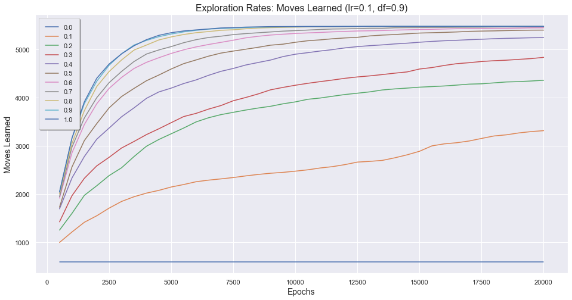

```python
ax = moves_edf.plot(figsize=(16, 8))
ax.set_title('Exploration Rates: Moves Learned (lr=' + str(lrn) + ', df=' + str(dsc) + ')', fontsize= 16)
ax.set_xlabel("Epochs", fontsize=14)
ax.set_ylabel("Moves Learned", fontsize=14)
plt.legend(fancybox=True, framealpha=1, shadow=True, borderpad=1)

fig = ax.get_figure()
fig.savefig('tictactoe_graphs/Exploration Rate - Moves.jpg', format='jpeg', dpi=200, bbox_inches='tight')
plt.show()
```

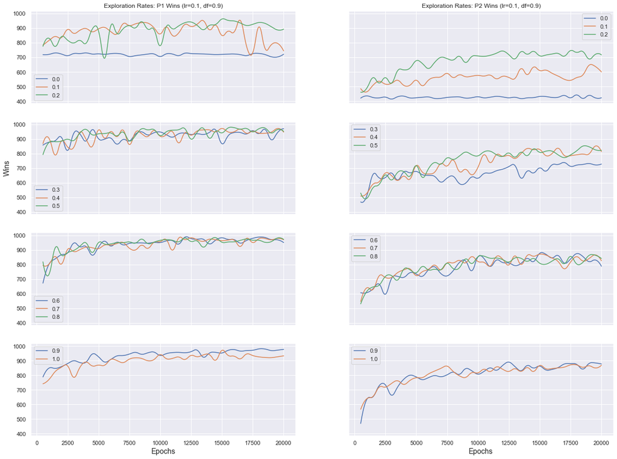

```python
fig, ax = plt.subplots(4,2, figsize=(20, 15), sharex=True, sharey=True)
ax[0][0] = P1_edf.iloc[:,0:3].plot(title='Exploration Rates: P1 Wins (lr=' + str(lrn) + ', df=' + str(dsc) + ')', ax=ax[0][0])
ax[1][0] = P1_edf.iloc[:,3:6].plot(ax=ax[1][0])
ax[2][0] = P1_edf.iloc[:,6:9].plot(ax=ax[2][0])
ax[2][0] = P1_edf.iloc[:,9:11].plot(ax=ax[3][0])

ax[0][1] = P2_edf.iloc[:,0:3].plot(title='Exploration Rates: P2 Wins (lr=' + str(lrn) + ', df=' + str(dsc) + ')', ax=ax[0][1])
ax[1][1] = P2_edf.iloc[:,3:6].plot( ax=ax[1][1])
ax[2][1] = P2_edf.iloc[:,6:9].plot(ax=ax[2][1])
ax[2][0] = P2_edf.iloc[:,9:11].plot(ax=ax[3][1])

ax[1][0].set_ylabel("Wins", fontsize=14)
ax[3][0].set_xlabel("Epochs", fontsize=14)
ax[3][1].set_xlabel("Epochs", fontsize=14)

plt.show()
fig.savefig('tictactoe_graphs/Exploration Rate - Wins.jpg', format='jpeg', dpi=200, bbox_inches='tight')
```

#### Testing the learn rate

```python
test = 'l'

moves_l, P1_l, P2_l = parameter_test(test=test, exp=exp, dsc=dsc, start_epc=start, max_epc=max_epochs, inter_epc=interval)
moves_ldf, P1_ldf, P2_ldf = interpolate_df(start, max_epochs, interval, moves_l, P1_l, P2_l)
```

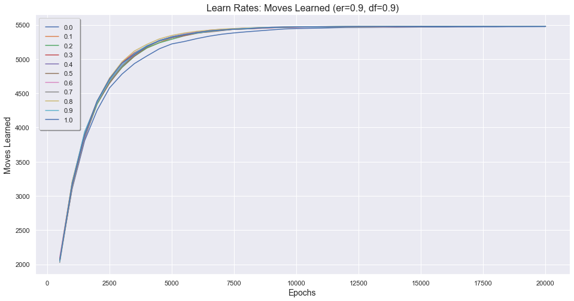

```python
ax = moves_ldf.plot(figsize=(16, 8))
ax.set_title('Learn Rates: Moves Learned (er=' + str(exp) + ', df=' + str(dsc) + ')', fontsize= 16)
ax.set_xlabel("Epochs", fontsize=14)
ax.set_ylabel("Moves Learned", fontsize=14)
plt.legend(fancybox=True, framealpha=1, shadow=True, borderpad=1)

fig = ax.get_figure()
fig.savefig('tictactoe_graphs/Learn Rate - Moves.jpg', format='jpeg', dpi=200, bbox_inches='tight')
plt.show()
```

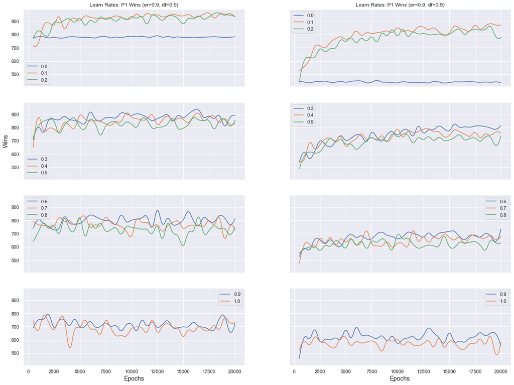

```python
fig, ax = plt.subplots(4,2, figsize=(20, 15), sharex=True, sharey=True)
ax[0][0] = P1_ldf.iloc[:,0:3].plot(title='Learn Rates: P1 Wins (er=' + str(exp) + ', df=' + str(dsc) + ')', ax=ax[0][0])
ax[1][0] = P1_ldf.iloc[:,3:6].plot(ax=ax[1][0])
ax[2][0] = P1_ldf.iloc[:,6:9].plot(ax=ax[2][0])
ax[2][0] = P1_ldf.iloc[:,9:11].plot(ax=ax[3][0])

ax[0][1] = P2_ldf.iloc[:,0:3].plot(title='Learn Rates: P1 Wins (er=' + str(exp) + ', df=' + str(dsc) + ')', ax=ax[0][1])
ax[1][1] = P2_ldf.iloc[:,3:6].plot( ax=ax[1][1])
ax[2][1] = P2_ldf.iloc[:,6:9].plot(ax=ax[2][1])
ax[2][0] = P2_ldf.iloc[:,9:11].plot(ax=ax[3][1])

ax[1][0].set_ylabel("Wins", fontsize=14)
ax[3][0].set_xlabel("Epochs", fontsize=14)
ax[3][1].set_xlabel("Epochs", fontsize=14)

plt.show()
fig.savefig('tictactoe_graphs/Learn Rate - Wins.jpg', format='jpeg', dpi=200, bbox_inches='tight')
```

#### Testing the discount factor

```python
test = 'd'

moves_d, P1_d, P2_d = parameter_test(test=test, exp=exp, lrn=lrn, start_epc=start, max_epc=max_epochs, inter_epc=interval)
moves_ddf, P1_ddf, P2_ddf = interpolate_df(start, max_epochs, interval, moves_d, P1_d, P2_d)
```

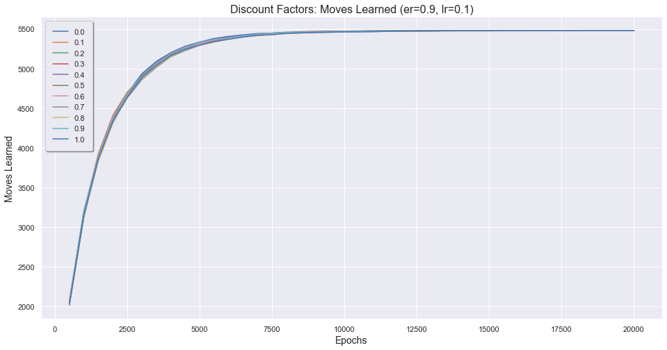

```python
ax = moves_ddf.plot(figsize=(16, 8))
ax.set_title('Discount Factors: Moves Learned (er=' + str(exp) + ', lr=' + str(lrn) + ')', fontsize= 16)
ax.set_xlabel("Epochs", fontsize=14)
ax.set_ylabel("Moves Learned", fontsize=14)
plt.legend(fancybox=True, framealpha=1, shadow=True, borderpad=1)

fig = ax.get_figure()
fig.savefig('tictactoe_graphs/Discount Rate - Moves.jpg', format='jpeg', dpi=200, bbox_inches='tight')
plt.show()
```

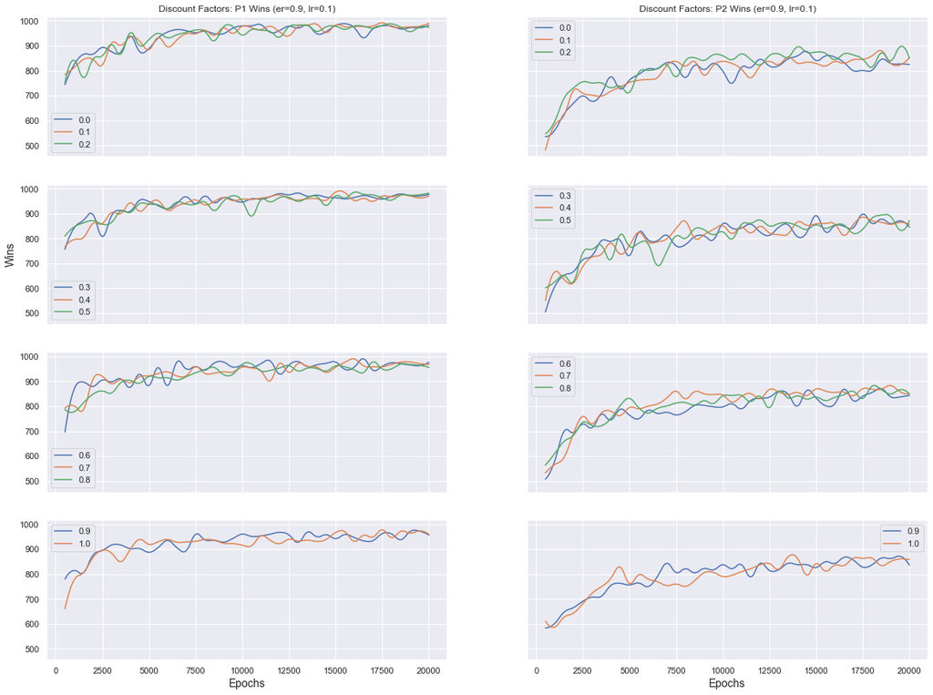

```python
fig, ax = plt.subplots(4,2, figsize=(20, 15), sharex=True, sharey=True)
ax[0][0] = P1_ddf.iloc[:,0:3].plot(title='Discount Factors: P1 Wins (er=' + str(exp) + ', lr=' + str(lrn) + ')', ax=ax[0][0])
ax[1][0] = P1_ddf.iloc[:,3:6].plot(ax=ax[1][0])
ax[2][0] = P1_ddf.iloc[:,6:9].plot(ax=ax[2][0])
ax[2][0] = P1_ddf.iloc[:,9:11].plot(ax=ax[3][0])

ax[0][1] = P2_ddf.iloc[:,0:3].plot(title='Discount Factors: P2 Wins (er=' + str(exp) + ', lr=' + str(lrn) + ')', ax=ax[0][1])
ax[1][1] = P2_ddf.iloc[:,3:6].plot( ax=ax[1][1])
ax[2][1] = P2_ddf.iloc[:,6:9].plot(ax=ax[2][1])
ax[2][0] = P2_ddf.iloc[:,9:11].plot(ax=ax[3][1])

ax[1][0].set_ylabel("Wins", fontsize=14)
ax[3][0].set_xlabel("Epochs", fontsize=14)
ax[3][1].set_xlabel("Epochs", fontsize=14)

plt.show()
fig.savefig('tictactoe_graphs/Discount Factor - Wins.jpg', format='jpeg', dpi=200, bbox_inches='tight')
```

From these results we can see that higher exploration rates and lower learn rates are prefered for the model. The discount factor appears to have little impact on the accuracy of the model however, higher values marginally improve it. Good values for the 3 parameters appear to be:

- exploration rate = 0.9
- learn rate = 0.1
- discount factor = 1.0

Given these values, the accuracy of the tests stop being significantly by further epochs at around 15000 epochs.

### Re-running the model test

Using these values we can run our tests again to get the maximum accuracy capable for this model.

```python
exploration = 0.9
learn = 0.1
discount = 1.0
epochs = 15000
trials = 10
games_per_trial = 1000

tester = Tester(N=3, exp=exploration, lrn=learn, dsc=discount)
tester.build_model(epochs)

P1_test_wdl, P1_test_turns = tester.test_model(player_list=['b', 'r'], moves_list=[6, 8])
P2_test_wdl, P2_test_turns = tester.test_model(player_list=['r', 'b'], moves_list=[5, 7])

P1_control_win = (sum(P1_control_wdl['wins'])/(games_per_trial * trials)) * 100
P1_test_win = (sum(P1_test_wdl['wins'])/(games_per_trial * trials)) * 100
P2_control_win = (sum(P2_control_wdl['wins'])/(games_per_trial * trials)) * 100
P2_test_win = (sum(P2_test_wdl['wins'])/(games_per_trial * trials)) * 100

print("Player 1: Control Win % =", P1_control_win, ", Player 1: Test Win % =", P1_test_win)
print("Player 2: Control Win % =", P2_control_win, ", Player 2: Test Win % =", P2_test_win)
```

```
 Learned 5476 possible moves out of 5477
```

```
 Results for Player 1
938 average wins out of 1000 - [942, 950, 938, 945, 932, 937, 940, 933, 935, 927]
42 average draws out of 1000 - [40, 35, 43, 29, 38, 53, 42, 48, 42, 46]
20 average losses out of 1000 - [18, 15, 19, 26, 30, 10, 18, 19, 23, 27]
7 average losses on 6 turns 1000
20 average losses on 8 turns 1000
 Total learned Epochs for Player 1 15000
 Total learned Epochs for Player 2 15000
```

```
 Results for Player 2
879 average wins out of 1000 - [890, 878, 874, 884, 862, 875, 875, 884, 890, 875]
34 average draws out of 1000 - [33, 39, 35, 25, 43, 30, 32, 31, 30, 41]
87 average losses out of 1000 - [77, 83, 91, 91, 95, 95, 93, 85, 80, 84]
27 average losses on 5 turns 1000
48 average losses on 7 turns 1000
 Total learned Epochs for Player 1 15000
 Total learned Epochs for Player 2 15000

Player 1: Control Win % = 58.19 , Player 1: Test Win % = 93.78999999999999
Player 2: Control Win % = 28.389999999999997 , Player 2: Test Win % = 87.87
```